# Prediction of soft churn and rock star

### data prepareation

1. Target Variables:

(1) we consider churn and readingDayNum of next month as Target Variables

(2) need to create new variable: if it is soft churn next month or not: for each sunscription ID, and each month, create: (Q4 need to be discussed) 'churn_next_month'(0,1),'soft_churn_next_month'(0,1),'rock_star_next_month','log_readingDayNum_next_month'

1. Predictive variables

(3)predictive variables:to make it simple, mainly consider behavior of a single month, the only historical data considerded would be month (the length of subscription)

Variables might be used (as first draft, can add more later, or, use simply use all of them? Professor seems xpectiong all 100+ features): SubscriptionType, Description, month, churn, time, pv, readingDayNum, sessionNum, timePV, pvDay, sessionDay, device_type, readings of major topics (might need to take log for some of them)

```python
# make list of variables  types
# numerical: discrete vs continuous
discrete = [var for var in train.columns if train[var].dtype!='O' and train[var].nunique() <= 2 and var != 'start_date_year']
continuous = [var for var in train.columns if train[var].dtype!='O' and var not in discrete]

# categorical
categorical = [var for var in train.columns if train[var].dtype=='O' ]

print('There are {} discrete variables'.format(len(discrete)))
print('There are {} continuous variables'.format(len(continuous)))
print('There are {} categorical variables'.format(len(categorical)))
```

```
There are 12 discrete variables
There are 109 continuous variables
There are 11 categorical variables
```

```python
discrete
```

```
['multiStop',
 'leftCensored',
 'censorDaysL',
 'churn',
 'isEngage',
 'adBlock',
 'train',
 'churn_next_month',
 'churn_last_month',
 'readingDayNum_last_month_NA',
 'churn_last_month_NA',
 'readingDayNum_last_month2_NA']
```

```python
train['multiStop'] = np.where(train['multiStop'] == True, 1, 0).copy()
new = train[discrete]
new.head()
```

|  | multiStop | leftCensored | censorDaysL | churn | isEngage | adBlock | train | churn_next_month | churn_last_month | readingDayNum_last_month_NA | churn_last_month_NA | readingDayNum_last_month2_NA |
| --- | --- | --- | --- | --- | --- | --- | --- | --- | --- | --- | --- | --- |
| 3 | 1 | 0 | 0 | 0 | 1 | 0 | True | 1.0 | 0.0 | 0 | 0 | 0 |
| 2 | 1 | 0 | 0 | 0 | 1 | 0 | True | 0.0 | 0.0 | 0 | 0 | 0 |
| 1 | 1 | 0 | 0 | 0 | 1 | 0 | True | 0.0 | 0.0 | 0 | 0 | 1 |
| 0 | 1 | 0 | 0 | 0 | 1 | 0 | True | 0.0 | 0.0 | 1 | 1 | 1 |
| 5 | 1 | 0 | 0 | 0 | 1 | 0 | True | 1.0 | 0.0 | 1 | 1 | 1 |

```python
continuous[0:10]
```

```
['DeliveryScheduleUc',
 'month',
 'time',
 'pv',
 'readingDayNum',
 'sessionNum',
 'timePV',
 'pvDay',
 'sessionDay',
 'entropy']
```

```python
categorical[0:10]
```

```
['ProductUc',
 'SubscriptionType',
 'Description',
 'device_type',
 'referrer_type',
 'first_hit_referrer_type',
 'geo_city',
 'geo_region',
 'geo_country',
 'ad_block_status']
```

```python
# let's inspect the variable values
for var in categorical:
    print(var, len(train[var].unique()))

# geo_city 900+, geo_region 100+, geo_country 50+ have too many variables, need to reduce them.
```

```
ProductUc 1
SubscriptionType 2
Description 8
device_type 4
referrer_type 7
first_hit_referrer_type 6
geo_city 1242
geo_region 191
geo_country 60
ad_block_status 4
season 4
```

```python
# let's explore examples in which variables have several categories, say more than 10
multi_cat_cols = []
for col in train.columns:
    if train[col].dtypes =='O': # if variable  is categorical
        if train[col].nunique() >= 10: # and has more than 10 categories
            multi_cat_cols.append(col)  # add to the list
print(multi_cat_cols) # and print the percentage of observations within each category
```

```
['geo_city', 'geo_region', 'geo_country']
```

### Encode Categorical variable (Rare-one-hot-encoding)

```python
# check variable frequency, find a resonable threshod (0.01)
for var in multi_cat_cols:
    print((train[var].value_counts() / len(train)).sort_values()[-10:])
```

```
richmond         0.009010
sacramento       0.009231
(not set)        0.009287
new york         0.009564
san rafael       0.013168
san jose         0.014498
berkeley         0.014720
oakland          0.044632
san francisco    0.195437
Missing          0.319990
Name: geo_city, dtype: float64
District of Columbia    0.003548
Florida                 0.003964
Hawaii                  0.004075
Nevada                  0.004241
Washington              0.004713
Texas                   0.006431
Oregon                  0.008178
New York                0.011227
Missing                 0.319990
California              0.575056
Name: geo_region, dtype: float64
Costa Rica        0.000499
Philippines       0.000527
France            0.000610
Italy             0.000665
Japan             0.000693
Mexico            0.000915
Canada            0.001109
United Kingdom    0.001275
Missing           0.319990
United States     0.667896
Name: geo_country, dtype: float64
```

```python
def find_non_rare_labels(df, variable, tolerance):
    temp = df.groupby([variable])[variable].count() / len(df)
    non_rare = [x for x in temp.loc[temp>tolerance].index.values]
    return non_rare

def rare_encoding(X_train, X_test, variable, tolerance):

    X_train = X_train.copy()
    X_test = X_test.copy()
    # find the most frequent category
    frequent_cat = find_non_rare_labels(X_train, variable, tolerance)
    # re-group rare labels
    X_train[variable] = np.where(X_train[variable].isin(
        frequent_cat), X_train[variable], 'Rare')
    X_test[variable] = np.where(X_test[variable].isin(
        frequent_cat), X_test[variable], 'Rare')
    return X_train, X_test

for variable in multi_cat_cols:
    train, test = rare_encoding(train, test, variable, 0.01)

for var in categorical:
    print(var, len(train[var].unique()))
```

```
ProductUc 1
SubscriptionType 2
Description 8
device_type 4
referrer_type 7
first_hit_referrer_type 6
geo_city 7
geo_region 4
geo_country 3
ad_block_status 4
season 4
```

```python
# plt.figure(figsize=(20,20))
# sns.set_context("paper", font_scale=1)
# df_LC = train.copy()
# ## finding the correllation matrix and changing the categorical data to category for the plot.
# sns.heatmap(df_LC.assign(season=df_LC.season.astype('category').cat.codes,
#                          SubscriptionType=df_LC.SubscriptionType.astype('category').cat.codes).corr(),
#                          annot=True, cmap='bwr',vmin=-1, vmax=1, square=True, linewidths=0.5)
```

```python
# One-hot-encoding for categorical variables
train_dummies = pd.get_dummies(train[categorical])
test_dummies = pd.get_dummies(test[categorical])
# Get missing columns in the training test
missing_cols = set( train_dummies.columns ) - set( test_dummies.columns )
# Add a missing column in test set with default value equal to 0
for c in missing_cols:
    test_dummies[c] = 0
print(train_dummies.shape)
print(test_dummies.shape)
train_dummies.head()
```

```
(36073, 55)
(17886, 55)
```

[output not shown]

5 rows × 55 columns

```python
# train_dummies.dtypes
```

### For numerical variables, might need to transform(Log)

```python
# let's explore the distribution of the numerical variables
# train[continuous[0:50]].hist(figsize=(20,20))
# plt.show()
```

```python
# train[continuous[51:]].hist(figsize=(20,20))
# plt.show()
```

```python
# 'abDisabledPct', 'abEnabledPct', 'abnoResponsePct','entropy','Unnamed: 0','month','sentimentScore','start_date_month','start_date_day'
# these variables do not need to log
continuous_not_log = ['abDisabledPct', 'abEnabledPct', 'abnoResponsePct','entropy','Unnamed: 0','month','sentimentScore','start_date_month','start_date_day']
train_continuous = train[continuous_not_log]
test_continuous = test[continuous_not_log]
train_continuous.head()
```

|  | abDisabledPct | abEnabledPct | abnoResponsePct | entropy | Unnamed: 0 | month | sentimentScore | start_date_month | start_date_day |
| --- | --- | --- | --- | --- | --- | --- | --- | --- | --- |
| 3 | 1.00 | 0.00 | 0.0 | 0.943348 | 1 | 4 | 0 | 3 | 10 |
| 2 | 1.00 | 0.00 | 0.0 | 0.692239 | 1 | 3 | 0 | 3 | 10 |
| 1 | 1.00 | 0.00 | 0.0 | 0.636514 | 1 | 2 | 0 | 3 | 10 |
| 0 | 0.75 | 0.25 | 0.0 | 1.039721 | 1 | 1 | -1 | 3 | 10 |
| 5 | 0.00 | 0.00 | 0.0 | 1.070047 | 2 | 1 | -6 | 6 | 19 |

```python
# add transfromed columns
for var in continuous:
    if var not in continuous_not_log:
        if min(train[var]) > -1:
            train_continuous[var] = np.log(1.0 + train[var])
            test_continuous[var] = np.log(1.0 + test[var])
#             train_continuous[var] = 1.0 - (1.0 / (1.0 + train[var]))
#             test_continuous[var] = 1.0 - (1.0 / (1.0 + test[var]))
        else:
            train_continuous[var] = train[var]
            test_continuous[var] = test[var]
train_continuous.head()
```

|  | abDisabledPct | abEnabledPct | abnoResponsePct | entropy | Unnamed: 0 | month | sentimentScore | start_date_month | start_date_day | DeliveryScheduleUc | time | pv | readingDayNum | sessionNum | timePV | pvDay | sessionDay | mobileUse | desktopUse | tabletUse | home | news:bay area & state | syncronex | news | news:crime | news:politics | business | sports | sports:golden state warriors | … |
| --- | --- | --- | --- | --- | --- | --- | --- | --- | --- | --- | --- | --- | --- | --- | --- | --- | --- | --- | --- | --- | --- | --- | --- | --- | --- | --- | --- | --- | --- | --- |
| 3 | 1.00 | 0.00 | 0.0 | 0.943348 | 1 | 4 | 0 | 3 | 10 | 16.916603 | 5.847435 | 2.397895 | 0.693147 | 1.098612 | 3.570504 | 2.397895 | 1.098612 | 0.000000 | 0.693147 | 0.0 | 1.609438 | 0.000000 | 1.791759 | 0.693147 | 0.0 | 0.0 | 0.00000 | 0.000000 | 0.0 | … |
| 2 | 1.00 | 0.00 | 0.0 | 0.692239 | 1 | 3 | 0 | 3 | 10 | 16.916603 | 8.275615 | 3.496508 | 1.386294 | 1.791759 | 4.817743 | 2.456736 | 0.980829 | 0.000000 | 0.693147 | 0.0 | 2.197225 | 0.000000 | 3.178054 | 0.000000 | 0.0 | 0.0 | 0.00000 | 0.000000 | 0.0 | … |
| 1 | 1.00 | 0.00 | 0.0 | 0.636514 | 1 | 2 | 0 | 3 | 10 | 16.916603 | 6.711064 | 2.302585 | 1.386294 | 1.609438 | 4.523531 | 1.386294 | 0.847298 | 0.000000 | 0.693147 | 0.0 | 1.945910 | 0.000000 | 1.386294 | 0.000000 | 0.0 | 0.0 | 0.00000 | 0.000000 | 0.0 | … |
| 0 | 0.75 | 0.25 | 0.0 | 1.039721 | 1 | 1 | -1 | 3 | 10 | 16.916603 | 5.647236 | 1.609438 | 0.693147 | 0.693147 | 4.271467 | 1.609438 | 0.693147 | 0.000000 | 0.693147 | 0.0 | 1.098612 | 0.693147 | 0.000000 | 0.000000 | 0.0 | 0.0 | 0.00000 | 0.000000 | 0.0 | … |
| 5 | 0.00 | 0.00 | 0.0 | 1.070047 | 2 | 1 | -6 | 6 | 19 | 16.916603 | 6.161753 | 3.044522 | 2.302585 | 2.484907 | 3.205302 | 1.170071 | 0.798508 | 0.610909 | 0.146603 | 0.0 | 0.000000 | 2.484907 | 0.000000 | 0.000000 | 0.0 | 0.0 | 1.94591 | 0.693147 | 0.0 | … |

```python
# train_continuous[continuous[0:50]].hist(figsize=(20,20))
# plt.show()
```

```python
# train_continuous[continuous[51:]].hist(figsize=(20,20))
# plt.show()
```

```python
# from feature_engine.discretisers import EqualFrequencyDiscretiser
# disc = EqualFrequencyDiscretiser(q=10, variables = continuous)
# disc.fit(train_continuous)
# # transform train and text
# train_continuous = disc.transform(train_continuous).copy()
# test_continuous = disc.transform(test_continuous).copy()
```

```python
train_continuous.describe()
```

|  | abDisabledPct | abEnabledPct | abnoResponsePct | entropy | Unnamed: 0 | month | sentimentScore | start_date_month | start_date_day | DeliveryScheduleUc | time | pv | readingDayNum | sessionNum | timePV | pvDay | sessionDay | mobileUse | desktopUse | tabletUse | home | news:bay area & state | syncronex | news | news:crime | news:politics | business | sports | sports:golden state warriors | … |
| --- | --- | --- | --- | --- | --- | --- | --- | --- | --- | --- | --- | --- | --- | --- | --- | --- | --- | --- | --- | --- | --- | --- | --- | --- | --- | --- | --- | --- | --- | --- |
| count | 36073.000000 | 36073.000000 | 36073.000000 | 36073.000000 | 36073.000000 | 36073.000000 | 36073.000000 | 36073.000000 | 36073.000000 | 36073.000000 | 36073.000000 | 36073.000000 | 36073.000000 | 36073.000000 | 36073.000000 | 36073.000000 | 36073.000000 | 36073.000000 | 36073.000000 | 36073.000000 | 36073.000000 | 36073.000000 | 36073.000000 | 36073.000000 | 36073.000000 | 36073.000000 | 36073.000000 | 36073.000000 | 36073.000000 | … |
| mean | 0.526006 | 0.079186 | 0.020595 | 0.855621 | 3963.389737 | 4.242065 | -6.028415 | 7.150778 | 16.759321 | 16.661224 | 4.364509 | 2.172315 | 1.318033 | 1.565034 | 2.338960 | 1.138605 | 0.639929 | 0.117815 | 0.306242 | 0.060419 | 0.960578 | 0.889578 | 0.381715 | 0.477055 | 0.357930 | 0.408110 | 0.368505 | 0.259405 | 0.171543 | … |
| std | 0.472011 | 0.235166 | 0.078594 | 0.859487 | 2750.639901 | 2.801880 | 20.893715 | 3.839226 | 9.224550 | 0.336984 | 3.874236 | 1.945883 | 1.167962 | 1.467738 | 2.058340 | 0.978341 | 0.525379 | 0.239962 | 0.327820 | 0.181865 | 1.550221 | 1.256963 | 0.935945 | 0.861351 | 0.784732 | 0.772153 | 0.720097 | 0.681675 | 0.594250 | … |
| min | 0.000000 | 0.000000 | 0.000000 | 0.000000 | 1.000000 | 1.000000 | -1102.000000 | 1.000000 | 1.000000 | 16.129146 | 0.000000 | 0.000000 | 0.000000 | 0.000000 | 0.000000 | 0.000000 | 0.000000 | 0.000000 | 0.000000 | 0.000000 | 0.000000 | 0.000000 | 0.000000 | 0.000000 | 0.000000 | 0.000000 | 0.000000 | 0.000000 | 0.000000 | … |
| 25% | 0.000000 | 0.000000 | 0.000000 | 0.000000 | 1595.000000 | 2.000000 | -4.000000 | 4.000000 | 8.000000 | 16.223456 | 0.000000 | 0.000000 | 0.000000 | 0.000000 | 0.000000 | 0.000000 | 0.000000 | 0.000000 | 0.000000 | 0.000000 | 0.000000 | 0.000000 | 0.000000 | 0.000000 | 0.000000 | 0.000000 | 0.000000 | 0.000000 | 0.000000 | … |
| 50% | 0.808511 | 0.000000 | 0.000000 | 0.693147 | 3376.000000 | 4.000000 | 0.000000 | 7.000000 | 18.000000 | 16.916603 | 5.162471 | 2.079442 | 1.098612 | 1.386294 | 2.903123 | 1.098612 | 0.693147 | 0.000000 | 0.030191 | 0.000000 | 0.000000 | 0.000000 | 0.000000 | 0.000000 | 0.000000 | 0.000000 | 0.000000 | 0.000000 | 0.000000 | … |
| 75% | 1.000000 | 0.000000 | 0.000000 | 1.639821 | 6351.000000 | 6.000000 | 0.000000 | 11.000000 | 25.000000 | 16.916603 | 7.830548 | 3.713572 | 2.302585 | 2.639057 | 4.192111 | 1.909543 | 0.916291 | 0.000000 | 0.693147 | 0.000000 | 1.609438 | 1.609438 | 0.000000 | 0.693147 | 0.000000 | 0.693147 | 0.693147 | 0.000000 | 0.000000 | … |
| max | 1.000000 | 1.000000 | 1.000000 | 3.326143 | 10427.000000 | 12.000000 | 131.000000 | 12.000000 | 31.000000 | 16.916603 | 13.803601 | 7.879670 | 3.496508 | 7.286192 | 7.492430 | 5.839672 | 3.882937 | 0.693147 | 0.693147 | 0.693147 | 7.304516 | 6.285998 | 7.047517 | 5.953243 | 6.073045 | 5.187386 | 5.389072 | 5.755742 | 5.690359 | … |

```python
X_train_scaled = train_continuous.copy()
X_test_scaled = test_continuous.copy()

for var in continuous:
    X_train_scaled[var] = (train_continuous[var] - min(train_continuous[var]))/(max(train_continuous[var])-min(train_continuous[var]))
    X_test_scaled[var] = (test_continuous[var] - min(train_continuous[var]))/(max(train_continuous[var])-min(train_continuous[var]))
```

```python
X_train_scaled.describe()
```

|  | abDisabledPct | abEnabledPct | abnoResponsePct | entropy | Unnamed: 0 | month | sentimentScore | start_date_month | start_date_day | DeliveryScheduleUc | time | pv | readingDayNum | sessionNum | timePV | pvDay | sessionDay | mobileUse | desktopUse | tabletUse | home | news:bay area & state | syncronex | news | news:crime | news:politics | business | sports | sports:golden state warriors | … |
| --- | --- | --- | --- | --- | --- | --- | --- | --- | --- | --- | --- | --- | --- | --- | --- | --- | --- | --- | --- | --- | --- | --- | --- | --- | --- | --- | --- | --- | --- | --- |
| count | 36073.000000 | 36073.000000 | 36073.000000 | 36073.000000 | 36073.000000 | 36073.000000 | 36073.000000 | 36073.000000 | 36073.000000 | 36073.000000 | 36073.000000 | 36073.000000 | 36073.000000 | 36073.000000 | 36073.000000 | 36073.000000 | 36073.000000 | 36073.000000 | 36073.000000 | 36073.000000 | 36073.000000 | 36073.000000 | 36073.000000 | 36073.000000 | 36073.000000 | 36073.000000 | 36073.000000 | 36073.000000 | 36073.000000 | … |
| mean | 0.526006 | 0.079186 | 0.020595 | 0.257241 | 0.380049 | 0.294733 | 0.888866 | 0.559162 | 0.525311 | 0.675691 | 0.316186 | 0.275686 | 0.376957 | 0.214794 | 0.312176 | 0.194978 | 0.164805 | 0.169970 | 0.441813 | 0.087166 | 0.131505 | 0.141517 | 0.054163 | 0.080134 | 0.058938 | 0.078674 | 0.068380 | 0.045069 | 0.030146 | … |
| std | 0.472011 | 0.235166 | 0.078594 | 0.258404 | 0.263825 | 0.254716 | 0.016945 | 0.349021 | 0.307485 | 0.427939 | 0.280669 | 0.246950 | 0.334037 | 0.201441 | 0.274723 | 0.167534 | 0.135305 | 0.346192 | 0.472944 | 0.262376 | 0.212228 | 0.199962 | 0.132805 | 0.144686 | 0.129216 | 0.148852 | 0.133622 | 0.118434 | 0.104431 | … |
| min | 0.000000 | 0.000000 | 0.000000 | 0.000000 | 0.000000 | 0.000000 | 0.000000 | 0.000000 | 0.000000 | 0.000000 | 0.000000 | 0.000000 | 0.000000 | 0.000000 | 0.000000 | 0.000000 | 0.000000 | 0.000000 | 0.000000 | 0.000000 | 0.000000 | 0.000000 | 0.000000 | 0.000000 | 0.000000 | 0.000000 | 0.000000 | 0.000000 | 0.000000 | … |
| 25% | 0.000000 | 0.000000 | 0.000000 | 0.000000 | 0.152887 | 0.090909 | 0.890511 | 0.272727 | 0.233333 | 0.119766 | 0.000000 | 0.000000 | 0.000000 | 0.000000 | 0.000000 | 0.000000 | 0.000000 | 0.000000 | 0.000000 | 0.000000 | 0.000000 | 0.000000 | 0.000000 | 0.000000 | 0.000000 | 0.000000 | 0.000000 | 0.000000 | 0.000000 | … |
| 50% | 0.808511 | 0.000000 | 0.000000 | 0.208394 | 0.323710 | 0.272727 | 0.893755 | 0.545455 | 0.566667 | 1.000000 | 0.373994 | 0.263900 | 0.314203 | 0.190263 | 0.387474 | 0.188129 | 0.178511 | 0.000000 | 0.043556 | 0.000000 | 0.000000 | 0.000000 | 0.000000 | 0.000000 | 0.000000 | 0.000000 | 0.000000 | 0.000000 | 0.000000 | … |
| 75% | 1.000000 | 0.000000 | 0.000000 | 0.493010 | 0.609054 | 0.454545 | 0.893755 | 0.909091 | 0.800000 | 1.000000 | 0.567283 | 0.471285 | 0.658539 | 0.362200 | 0.559513 | 0.326995 | 0.235979 | 0.000000 | 1.000000 | 0.000000 | 0.220335 | 0.256035 | 0.000000 | 0.116432 | 0.000000 | 0.133622 | 0.128621 | 0.000000 | 0.000000 | … |
| max | 1.000000 | 1.000000 | 1.000000 | 1.000000 | 1.000000 | 1.000000 | 1.000000 | 1.000000 | 1.000000 | 1.000000 | 1.000000 | 1.000000 | 1.000000 | 1.000000 | 1.000000 | 1.000000 | 1.000000 | 1.000000 | 1.000000 | 1.000000 | 1.000000 | 1.000000 | 1.000000 | 1.000000 | 1.000000 | 1.000000 | 1.000000 | 1.000000 | 1.000000 | … |

```python
type(X_train_scaled)
```

```
pandas.core.frame.DataFrame
```

```python
# X_train_scaled = pd.DataFrame(data=X_train_scaled[1:,1:],    # values
#                                           index=X_train_scaled[1:,0],    # 1st column as index
#                                           columns=X_train_scaled[0,1:])
# X_train_scaled.head()
```

```python
X_train = train_dummies
X_test = test_dummies
for var in continuous:
    X_train[var] = X_train_scaled[var]
    X_test[var] = X_test_scaled[var]
for var in discrete:
    X_train[var] = train[var]
    X_test[var] = test[var]

X_train = X_train.drop(['churn_next_month','readingDayNum_next_month','train'], axis=1).copy()
X_test = X_test.drop(['churn_next_month','readingDayNum_next_month','train'], axis=1).copy()
X_train.head()
```

|  | start_date_2017-11-26 | start_date_2017-11-27 | start_date_2017-11-28 | start_date_2017-11-29 | start_date_2017-12-31 | start_date_2018-01-01 | start_date_2018-06-06 | start_date_Rare | stop_date_2018-10-16 | stop_date_Rare | ProductUc_SfChron | SubscriptionType_D | SubscriptionType_P | Description_Fri-Sun | Description_Mon-Sat | Description_Mon-Sun | Description_Sun | Description_Universal Digital Access | Description_Wed-Sun | Description_eEdition | Description_iPad | device_type_Desktop | device_type_Mobile Phone | device_type_Tablet | referrer_type_Inside Your Site | referrer_type_NoRead | referrer_type_Other Web Sites | referrer_type_Others | referrer_type_Search Engines | … |
| --- | --- | --- | --- | --- | --- | --- | --- | --- | --- | --- | --- | --- | --- | --- | --- | --- | --- | --- | --- | --- | --- | --- | --- | --- | --- | --- | --- | --- | --- | --- |
| 3 | 0 | 0 | 0 | 0 | 0 | 0 | 0 | 1 | 0 | 1 | 1 | 1 | 0 | 0 | 0 | 0 | 0 | 0 | 0 | 1 | 0 | 1 | 0 | 0 | 1 | 0 | 0 | 0 | 0 | … |
| 2 | 0 | 0 | 0 | 0 | 0 | 0 | 0 | 1 | 0 | 1 | 1 | 1 | 0 | 0 | 0 | 0 | 0 | 0 | 0 | 1 | 0 | 1 | 0 | 0 | 1 | 0 | 0 | 0 | 0 | … |
| 1 | 0 | 0 | 0 | 0 | 0 | 0 | 0 | 1 | 0 | 1 | 1 | 1 | 0 | 0 | 0 | 0 | 0 | 0 | 0 | 1 | 0 | 1 | 0 | 0 | 1 | 0 | 0 | 0 | 0 | … |
| 0 | 0 | 0 | 0 | 0 | 0 | 0 | 0 | 1 | 0 | 1 | 1 | 1 | 0 | 0 | 0 | 0 | 0 | 0 | 0 | 1 | 0 | 1 | 0 | 0 | 1 | 0 | 0 | 0 | 0 | … |
| 5 | 0 | 0 | 0 | 0 | 0 | 0 | 0 | 1 | 0 | 1 | 1 | 1 | 0 | 0 | 0 | 0 | 0 | 1 | 0 | 0 | 0 | 0 | 1 | 0 | 1 | 0 | 0 | 0 | 0 | … |

```python
# np.any(np.isnan(logReadingDayNum_next_month_test.any()))
# np.all(np.isfinite(logReadingDayNum_next_month_test.all()))
np.where(X_test.values >= np.finfo(np.float64).max)
```

```
(array([], dtype=int64), array([], dtype=int64))
```

```python
# X_train = pd.DataFrame(X_train)
# X_test = pd.DataFrame(X_test)
# pd.set_option('display.max_columns', None)
# X_train.head()
# X_train.describe()
```

```python
# create variable y
churn_next_month_train = train['churn_next_month']
churn_next_month_test = test['churn_next_month']

logReadingDayNum_next_month_train = np.log(1.0 + train['readingDayNum_next_month'])
logReadingDayNum_next_month_test = np.log(1.0 + test['readingDayNum_next_month'])
# logReadingDayNum_next_month_train = 1.0 - (1.0 / (1.0 + train['readingDayNum_next_month']))
# logReadingDayNum_next_month_test = 1.0 - (1.0 / (1.0 + test['readingDayNum_next_month']))

rock_star_next_month_train = np.where(train['readingDayNum_next_month'] >= 20, 1, 0)
rock_star_next_month_test = np.where(test['readingDayNum_next_month'] >= 20, 1, 0)

soft_churn_next_month = np.where(train['readingDayNum_next_month'] <= 2, 1, 0)
soft_churn_next_test = np.where(test['readingDayNum_next_month'] <= 2, 1, 0)
```

```python
print(train_dummies.shape)
print(test_dummies.shape)
print(X_train.shape)
print(X_test.shape)
print(churn_next_month_train.shape)
print(churn_next_month_test.shape)
print(logReadingDayNum_next_month_train.shape)
print(logReadingDayNum_next_month_test.shape)
print(rock_star_next_month_train.shape)
print(rock_star_next_month_test.shape)
print(soft_churn_next_month.shape)
print(soft_churn_next_test.shape)
print(type(churn_next_month_train))
print(type(logReadingDayNum_next_month_train))
print(type(soft_churn_next_month))
print(type(rock_star_next_month_train))
```

```
(36073, 176)
(17886, 176)
(36073, 173)
(17886, 173)
(36073,)
(17886,)
(36073,)
(17886,)
(36073,)
(17886,)
(36073,)
(17886,)
<class 'pandas.core.series.Series'>
<class 'pandas.core.series.Series'>
<class 'numpy.ndarray'>
<class 'numpy.ndarray'>
```

```python
# # output csv file for modeling
# X_train.to_csv('X_train.csv')
# X_test.to_csv('X_test.csv')
```

### predictive modeling

##### 1. Training and validation

since we have tons of data, Train-test split would be enough, no need for cross validation.

##### 2. modeling methods

(0) Linear regression/ logistic regerssion as baseline

(1) Lasso (down to 10-20 variables)

(2) Random forest (down to 10-20 variables)

(3) Feature selection by PCA (down to 10-15 variables) + NN

(4) Feature selection by Lasso + NN

(5) Feature selection by Random forest + NN

##### 3. Modeling:

Q1: predict churn_next_month (AUC)

Q2: predict rock_star_next_month (AUC)

Q3: predict log_readingDayNum_next_month (R square)

##### 4. other tasks and questions

Q4: maybe 2 classification (1) classification: is easier to explain to business people (2) more actionable; (3) clear objective(AUC)

Q5: need to be discussed. The architecture and tranning? Number of hidden layers? (try 1-3?)

### Prediction of log_readingDayNum_next_month (R square)

```python
from sklearn import datasets, linear_model
from sklearn.metrics import mean_squared_error, r2_score
from sklearn.linear_model import LogisticRegression
from sklearn.metrics import roc_auc_score
from sklearn.neural_network import MLPRegressor
from lightgbm import LGBMRegressor
from sklearn.ensemble import RandomForestRegressor
from sklearn.datasets import make_regression
```

```python
regr = linear_model.LinearRegression()
regr.fit(X_train, logReadingDayNum_next_month_train)
logReadingDayNum_next_month_pred = regr.predict(X_test)
print('Predict logReadingDayNum_next_month using LinearRegression: ')
# The mean squared error
print('Mean squared error: %.2f'
      % mean_squared_error(logReadingDayNum_next_month_test, logReadingDayNum_next_month_pred))
# The coefficient of determination: 1 is perfect prediction
print('Coefficient of determination: %.2f'
      % r2_score(logReadingDayNum_next_month_test, logReadingDayNum_next_month_pred))
```

```
Predict logReadingDayNum_next_month using LinearRegression:
Mean squared error: 11250869009720215202693120.00
Coefficient of determination: -8452552615398358703407104.00
```

```python
# from sklearn.preprocessing import StandardScaler
# scaler = StandardScaler()
# # Fit on training set only.
# scaler.fit(X_train)
# # Apply transform to both the training set and the test set.
# X_train = scaler.transform(X_train)
# X_test = scaler.transform(X_test)

from sklearn.decomposition import PCA
# Make an instance of the Model
pca = PCA(.95)
pca.fit(X_train)
X_train_pca = pca.transform(X_train)
X_test_pca = pca.transform(X_test)
```

```python
# Create linear regression object
regr = linear_model.LinearRegression()
regr.fit(X_train_pca, logReadingDayNum_next_month_train)
logReadingDayNum_next_month_pred = regr.predict(X_test_pca)
print('Prediction logReadingDayNum_next_month using pca.95: ')
# The mean squared error
print('Mean squared error: %.2f'
      % mean_squared_error(logReadingDayNum_next_month_test, logReadingDayNum_next_month_pred))
# The coefficient of determination: 1 is perfect prediction
print('Coefficient of determination: %.2f'
      % r2_score(logReadingDayNum_next_month_test, logReadingDayNum_next_month_pred))
```

```
Prediction logReadingDayNum_next_month using pca.95:
Mean squared error: 0.49
Coefficient of determination: 0.63
```

Try only 2 Variables, the regression works...

```python
X_train1 = X_train[['readingDayNum','time']]
X_test1 = X_test[['readingDayNum','time']]

# Create linear regression object
regr = linear_model.LinearRegression()

regr.fit(X_train1, logReadingDayNum_next_month_train)
logReadingDayNum_next_month_pred = regr.predict(X_test1)

# The coefficients
# print('Coefficients: \n', regr.coef_)
# The mean squared error
print('Prediction logReadingDayNum_next_month using only readingDayNum and time')
print('Mean squared error: %.2f'
      % mean_squared_error(logReadingDayNum_next_month_test, logReadingDayNum_next_month_pred))
# The coefficient of determination: 1 is perfect prediction
print('Coefficient of determination: %.2f'
      % r2_score(logReadingDayNum_next_month_test, logReadingDayNum_next_month_pred))
```

```
Prediction logReadingDayNum_next_month using only readingDayNum and time
Mean squared error: 0.44
Coefficient of determination: 0.67
```

```python
train_dummies1 = train_dummies.drop(['churn_next_month'], axis=1).copy()
test_dummies1 = test_dummies.drop(['churn_next_month'], axis=1).copy()

model = LogisticRegression(max_iter=1000, solver="lbfgs")
model.fit(train_dummies1, churn_next_month_train)

predictions = model.predict(test_dummies1)
print('AUC: ', roc_auc_score(churn_next_month_test, predictions))
```

```
AUC:  0.7261215471692626
```

```python
pd.set_option('display.max_columns', None)
X_train.head()
```

|  | start_date_2017-11-26 | start_date_2017-11-27 | start_date_2017-11-28 | start_date_2017-11-29 | start_date_2017-12-31 | start_date_2018-01-01 | start_date_2018-06-06 | start_date_Rare | stop_date_2018-10-16 | stop_date_Rare | ProductUc_SfChron | SubscriptionType_D | SubscriptionType_P | Description_Fri-Sun | Description_Mon-Sat | Description_Mon-Sun | Description_Sun | Description_Universal Digital Access | Description_Wed-Sun | Description_eEdition | Description_iPad | device_type_Desktop | device_type_Mobile Phone | device_type_Tablet | referrer_type_Inside Your Site | referrer_type_NoRead | referrer_type_Other Web Sites | referrer_type_Others | referrer_type_Search Engines | … |
| --- | --- | --- | --- | --- | --- | --- | --- | --- | --- | --- | --- | --- | --- | --- | --- | --- | --- | --- | --- | --- | --- | --- | --- | --- | --- | --- | --- | --- | --- | --- |
| 3 | 0 | 0 | 0 | 0 | 0 | 0 | 0 | 1 | 0 | 1 | 1 | 1 | 0 | 0 | 0 | 0 | 0 | 0 | 0 | 1 | 0 | 1 | 0 | 0 | 1 | 0 | 0 | 0 | 0 | … |
| 2 | 0 | 0 | 0 | 0 | 0 | 0 | 0 | 1 | 0 | 1 | 1 | 1 | 0 | 0 | 0 | 0 | 0 | 0 | 0 | 1 | 0 | 1 | 0 | 0 | 1 | 0 | 0 | 0 | 0 | … |
| 1 | 0 | 0 | 0 | 0 | 0 | 0 | 0 | 1 | 0 | 1 | 1 | 1 | 0 | 0 | 0 | 0 | 0 | 0 | 0 | 1 | 0 | 1 | 0 | 0 | 1 | 0 | 0 | 0 | 0 | … |
| 0 | 0 | 0 | 0 | 0 | 0 | 0 | 0 | 1 | 0 | 1 | 1 | 1 | 0 | 0 | 0 | 0 | 0 | 0 | 0 | 1 | 0 | 1 | 0 | 0 | 1 | 0 | 0 | 0 | 0 | … |
| 5 | 0 | 0 | 0 | 0 | 0 | 0 | 0 | 1 | 0 | 1 | 1 | 1 | 0 | 0 | 0 | 0 | 0 | 1 | 0 | 0 | 0 | 0 | 1 | 0 | 1 | 0 | 0 | 0 | 0 | … |

```python
X_train1 = X_train[['readingDayNum','time','sessionNum','sessionDay','pvDay',
                    'season_Fall','season_Spring','season_Summer','season_Winter'
                   ]]
X_test1 = X_test[['readingDayNum','time','sessionNum','sessionDay','pvDay',
                    'season_Fall','season_Spring','season_Summer','season_Winter'
                   ]]
```

```python
# Create linear regression object
regr = linear_model.LinearRegression()

regr.fit(X_train1, logReadingDayNum_next_month_train)
logReadingDayNum_next_month_pred = regr.predict(X_test1)

# The coefficients
# print('Coefficients: \n', regr.coef_)
# The mean squared error
print('Mean squared error: %.2f'
      % mean_squared_error(logReadingDayNum_next_month_test, logReadingDayNum_next_month_pred))
# The coefficient of determination: 1 is perfect prediction
print('Coefficient of determination: %.2f'
      % r2_score(logReadingDayNum_next_month_test, logReadingDayNum_next_month_pred))
```

```
Mean squared error: 0.41
Coefficient of determination: 0.69
```

```python
clf = linear_model.Lasso(alpha=0.002, random_state=1108)
clf.fit(X_train, logReadingDayNum_next_month_train)
print('Prediction logReadingDayNum_next_month using Lasso:')
# print(clf.coef_)
print(clf.intercept_)
logReadingDayNum_next_month_pred = clf.predict(X_test)
print('Mean squared error: %.2f'
      % mean_squared_error(logReadingDayNum_next_month_test, logReadingDayNum_next_month_pred))
# The coefficient of determination: 1 is perfect prediction
print('Coefficient of determination: %.2f'
      % r2_score(logReadingDayNum_next_month_test, logReadingDayNum_next_month_pred))
cols = []

important_features = []
for i in X_train.columns:
    cols.append(i)
l = list(zip(clf.coef_, cols))
for i in l:
     if abs(float(i[0]))>= 0.0000000001:
        important_features.append(i[1])
        print(i)
print(important_features)
len(important_features)
```

```
Prediction logReadingDayNum_next_month using Lasso:
0.7571469362904586
Mean squared error: 0.46
Coefficient of determination: 0.65
(-0.02605630014554598, 'start_date_Rare')
(0.00609467896415905, 'stop_date_2018-10-16')
(0.0342365574327506, 'SubscriptionType_D')
(-0.037417404523207666, 'referrer_type_Inside Your Site')
(0.0254573351624611, 'referrer_type_NoRead')
(0.016834102601093665, 'first_hit_referrer_type_Others')
(-0.04681119313057952, 'first_hit_referrer_type_Search Engines')
(-0.01814589413343237, 'geo_city_Rare')
(0.006540366237684028, 'geo_city_san francisco')
(-0.31454373951690096, 'season_Fall')
(0.03164995009526849, 'season_Spring')
(0.040811418251688596, 'season_Summer')
(-0.044776053574670065, 'season_Winter')
(-0.34967205944159935, 'month')
(2.5201904174805705, 'readingDayNum')
(0.0071722130430683095, 'mobileUse')
(-0.002414352326948058, 'desktopUse')
(-0.027416660832716457, 'abDisabledPct')
(0.08456078302612965, 'home')
(0.1691378096715061, 'news:bay area & state')
(0.18366274080174794, 'news')
(0.02470354317668638, 'news:politics')
(0.0008357655145750759, 'sports')
(0.06001040872509119, 'sports:golden state warriors')
(0.09473480106625853, 'sports:giants')
(0.006464581762641746, 'sports:sports columnists')
(-0.12492916182402536, 'entertainment:blogs')
(-0.0994366676846615, 'Unnamed: 0')
(0.5591803396708465, 'readingDayNum_last_month')
(-0.008981137624524523, 'readingDayNum_last_month2')
(-0.38245355698363337, 'start_date_year')
(-0.37528909063201654, 'start_date_month')
(-0.013237419806220558, 'start_date_day')
(-0.045658780576479575, 'multiStop')
(-0.27580243799130805, 'isEngage')
(-0.07684637900155408, 'readingDayNum_last_month_NA')
['start_date_Rare', 'stop_date_2018-10-16', 'SubscriptionType_D', 'referrer_type_Inside Your Site', 'referrer_type_NoRead', 'first_hit_referrer_type_Others', 'first_hit_referrer_type_Search Engines', 'geo_city_Rare', 'geo_city_san francisco', 'season_Fall', 'season_Spring', 'season_Summer', 'season_…
```

```
36
```

```python
coef_dict = {}
for coef, feat in zip(clf.coef_,cols):
    coef_dict[feat] = coef
sorted_x = dict(sorted(coef_dict.items(), key=lambda kv: abs(kv[1]), reverse=True)[:20])
type(sorted_x)
```

```
dict
```

[figure not shown]

```python
# r = pd.DataFrame(columns=['Feature','Importance'])
# ncomp = 15
# r['Feature'] = feat_labels = Features.columns
# r['Importance'] = model.feature_importances_
# r.set_index(r['Feature'], inplace=True)
# ax = r.sort_values('Importance', ascending=False)[:ncomp].plot.bar(width=0.9, legend=False, figsize=(15,8))
# ax.set_ylabel('Relative Importance')

fig = plt.gcf()
fig.set_size_inches(15,7, forward = False)
plt.bar(sorted_x.keys(), sorted_x.values(), width = 1, color='g')
plt.xticks(rotation = 75)
plt.show()
```

```python
clf = MLPRegressor(solver='adam',activation='tanh', alpha=0.035,learning_rate = 'adaptive',
                   hidden_layer_sizes=(20,10,5,5,2),max_iter = 2000, random_state=1108,
                   early_stopping = False)
clf.fit(X_train[important_features], logReadingDayNum_next_month_train)
predictions = clf.predict(X_test[important_features])
predictiontrain = clf.predict(X_train[important_features])
# print(clf.coefs_)
print('Prediction logReadingDayNum_next_month using Lasso_filtered_features + NN:')
print('r2_score for train: ', r2_score(logReadingDayNum_next_month_train, predictiontrain))
print('r2_score for test: ', r2_score(logReadingDayNum_next_month_test, predictions))
```

```
Prediction logReadingDayNum_next_month using Lasso_filtered_features + NN:
r2_score for train:  0.7459134083410628
r2_score for test:  0.7303368958708352
```

```python
clf = MLPRegressor(solver='adam',activation='tanh', alpha=0.025,learning_rate = 'adaptive',
                   hidden_layer_sizes=(15,10,5),
                   max_iter = 2000, random_state=1108,
                   early_stopping = False)
clf.fit(X_train[important_features], logReadingDayNum_next_month_train)
predictions = clf.predict(X_test[important_features])
predictiontrain = clf.predict(X_train[important_features])
# print(clf.coefs_)
print('Prediction logReadingDayNum_next_month using Lasso_filtered_features + NN:')
print('r2_score for train: ', r2_score(logReadingDayNum_next_month_train, predictiontrain))
print('r2_score for test: ', r2_score(logReadingDayNum_next_month_test, predictions))
```

```
Prediction logReadingDayNum_next_month using Lasso_filtered_features + NN:
r2_score for train:  0.7465916615138275
r2_score for test:  0.7318289795363893
```

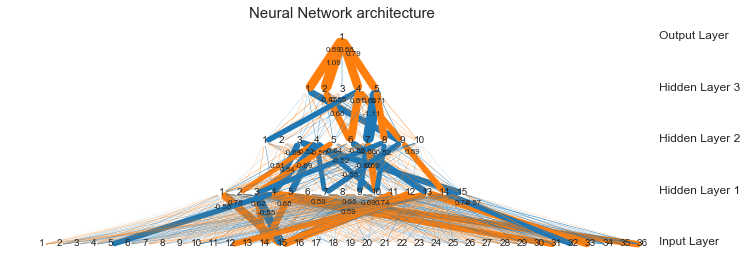

```python
import VisualizeNN as VisNN
import numpy as np

fig = plt.gcf()
fig.set_size_inches(15,25, forward = False)
network_structure = np.hstack(([X_train[important_features].shape[1]], np.asarray(clf.hidden_layer_sizes), 1))
network=VisNN.DrawNN(network_structure, clf.coefs_)
network.draw()
```

```python
clf = MLPRegressor(solver='adam',activation='tanh', alpha=0.01,learning_rate = 'adaptive',
                   hidden_layer_sizes=(5,2,2),max_iter = 1000, random_state=1108,
                   early_stopping = False)
clf.fit(X_train[newlist], logReadingDayNum_next_month_train)
predictions = clf.predict(X_test[newlist])
predictiontrain = clf.predict(X_train[newlist])
# print(clf.coefs_)
print('Prediction logReadingDayNum_next_month using Lasso_filtered_features + NN:')
print('r2_score for train: ', r2_score(logReadingDayNum_next_month_train, predictiontrain))
print('r2_score for test: ', r2_score(logReadingDayNum_next_month_test, predictions))
```

```
Prediction logReadingDayNum_next_month using Lasso_filtered_features + NN:
r2_score for train:  0.7310843345072906
r2_score for test:  0.7166600522157162
```

```python
# X_train_pca.shapey_train = logReadingDayNum_next_month_train
# y_train = logReadingDayNum_next_month_train[:2000]
# y_test = logReadingDayNum_next_month_test[:1000]
# alpha_list = [2**(i) for i in range(-20 , 15)]
# coefs_df = []
# mse_list = []

# for i in alpha_list:
#     clf.fit(X_train[:2000], y_train[:2000])
#     y_pred = clf.predict(X_test[:1000])

#     mse_list.append(mean_squared_error(y_test[:1000], y_pred, multioutput = 'raw_values')[0])
#     # store the coefficients of the variables in a list
#     coefs_df.append(pd.Series(clf.coefs_))

# coefs = pd.concat(coefs_df, axis=1)
# coefs.columns = [i for i in range(-20, 15)]
# coefs.index = X_train.columns

# plt.plot([i for i in range(-20, 15)], mse_list)
# plt.xlabel('Log2(alpha)')
# plt.ylabel("MSE")
```

```python
lgbm = LGBMRegressor(boosting_type='gbdt', num_leaves=31, max_depth= 8, learning_rate=0.01,
            n_estimators=1000, max_bin=255, subsample_for_bin=50000,
                     reg_alpha=0.25, reg_lambda=0.3, seed=1108)
lgbm.fit(X_train, logReadingDayNum_next_month_train)
predictions = lgbm.predict(X_test)
# print(clf.coefs_)
print('Prediction logReadingDayNum_next_month using Lasso_filtered_features + LGBM:')
print('r2_score: ', r2_score(logReadingDayNum_next_month_test, predictions))
```

```
Prediction logReadingDayNum_next_month using Lasso_filtered_features + LGBM:
r2_score:  0.5668872485696461
```

```python
# _, _, coefs = linear_model.lars_path(X_train.to_numpy(), churn_next_month_train.to_numpy(), method='lasso', verbose=True)

# xx = np.sum(np.abs(coefs.T), axis=1)
# xx /= xx[-1]

# plt.plot(xx, coefs.T)
# ymin, ymax = plt.ylim()
# plt.vlines(xx, ymin, ymax, linestyle='dashed')
# plt.xlabel('|coef| / max|coef|')
# plt.ylabel('Coefficients')
# plt.title('LASSO Path')
# plt.axis('tight')
# plt.show()
```

```python
regr = RandomForestRegressor(max_depth=5, random_state=1108,
                              n_estimators=100)
regr.fit(X_train, logReadingDayNum_next_month_train)
logReadingDayNum_next_month_pred = regr.predict(X_test)

print('Prediction logReadingDayNum_next_month using Lasso_filtered_features + RandomForest:')
# The mean squared error
print('Mean squared error: %.2f'
      % mean_squared_error(logReadingDayNum_next_month_test, logReadingDayNum_next_month_pred))
# The coefficient of determination: 1 is perfect prediction
print('Coefficient of determination: %.2f'
      % r2_score(logReadingDayNum_next_month_test, logReadingDayNum_next_month_pred))
```

```
Prediction logReadingDayNum_next_month using Lasso_filtered_features + RandomForest:
Mean squared error: 0.51
Coefficient of determination: 0.62
```

```python
regr = RandomForestRegressor(max_depth=10, random_state=1108,
                              n_estimators=100)
regr.fit(X_train, logReadingDayNum_next_month_train)
logReadingDayNum_next_month_pred = regr.predict(X_test)

print('Prediction logReadingDayNum_next_month RandomForest:')
# The mean squared error
print('Mean squared error: %.2f'
      % mean_squared_error(logReadingDayNum_next_month_test, logReadingDayNum_next_month_pred))
# The coefficient of determination: 1 is perfect prediction
print('Coefficient of determination: %.2f'
      % r2_score(logReadingDayNum_next_month_test, logReadingDayNum_next_month_pred))
```

```
Prediction logReadingDayNum_next_month RandomForest:
Mean squared error: 0.66
Coefficient of determination: 0.51
```

```python
cols = []

important_features = []
for i in X_train.columns:
    cols.append(i)
l = list(zip(lgbm.feature_importances_, cols))
for i in l:
     if abs(float(i[0]))>= 0.0000000001:
        important_features.append(i[1])
        print(i)
print(important_features)
len(important_features)
```

```
(2, 'start_date_2017-11-26')
(1, 'start_date_2017-11-27')
(1, 'start_date_2017-12-31')
(7, 'start_date_2018-01-01')
(87, 'start_date_Rare')
(295, 'stop_date_2018-10-16')
(155, 'SubscriptionType_D')
(9, 'Description_Fri-Sun')
(35, 'Description_Mon-Sun')
(35, 'Description_Sun')
(5, 'Description_Universal Digital Access')
(2, 'device_type_Desktop')
(13, 'device_type_Tablet')
(6, 'referrer_type_Inside Your Site')
(152, 'referrer_type_NoRead')
(15, 'referrer_type_Others')
(21, 'referrer_type_Search Engines')
(22, 'referrer_type_Social Networks')
(40, 'referrer_type_Typed/Bookmarked')
(123, 'first_hit_referrer_type_Others')
(165, 'first_hit_referrer_type_Search Engines')
(20, 'first_hit_referrer_type_Social Networks')
(73, 'first_hit_referrer_type_Typed/Bookmarked')
(127, 'geo_city_Rare')
(28, 'geo_city_berkeley')
(49, 'geo_city_oakland')
(57, 'geo_city_san francisco')
(20, 'geo_city_san jose')
(65, 'geo_region_California')
(5, 'geo_region_New York')
(36, 'geo_region_Rare')
(10, 'geo_country_Rare')
(5, 'ad_block_status_abDisabled')
(7, 'ad_block_status_abEnabled')
(1, 'ad_block_status_noResponse')
(1195, 'season_Fall')
(117, 'season_Spring')
(245, 'season_Summer')
(84, 'season_Winter')
(25, 'DeliveryScheduleUc')
```

[output cut: 86 more lines]

```
(33, 'entertainment:the wrap')
(409, 'nonHome')
(542, 'homePVPct')
(294, 'homePVDay')
(536, 'nonHomePVDay')
(657, 'sentimentScore')
(2469, 'Unnamed: 0')
(1523, 'readingDayNum_last_month')
(411, 'readingDayNum_last_month2')
(18, 'start_date_year')
(557, 'start_date_month')
(1190, 'start_date_day')
(111, 'multiStop')
(4, 'adBlock')
['start_date_2017-11-26', 'start_date_2017-11-27', 'start_date_2017-12-31', 'start_date_2018-01-01', 'start_date_Rare', 'stop_date_2018-10-16', 'SubscriptionType_D', 'Description_Fri-Sun', 'Description_Mon-Sun', 'Description_Sun', 'Description_Universal Digital Access', 'device_type_Desktop', 'devic…
```

```
140
```

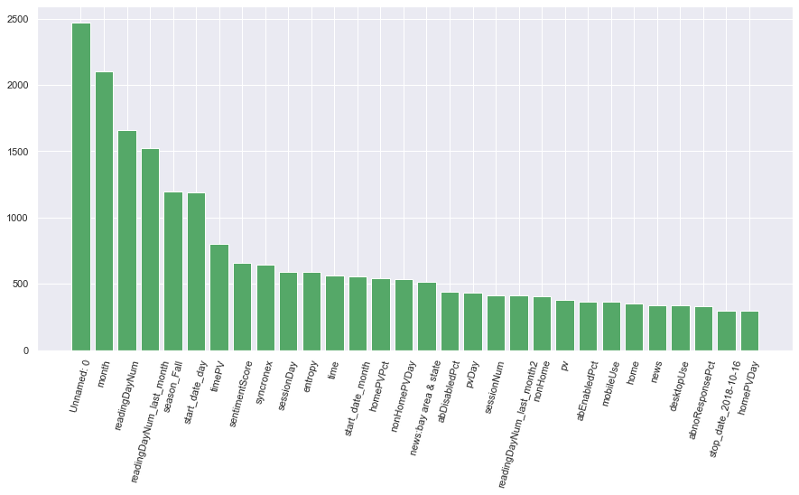

```
['Unnamed: 0',
 'month',
 'readingDayNum',
 'readingDayNum_last_month',
 'season_Fall',
 'start_date_day',
 'timePV',
 'sentimentScore',
 'syncronex',
 'sessionDay',
 'entropy',
 'time',
 'start_date_month',
 'homePVPct',
 'nonHomePVDay',
 'news:bay area & state',
 'abDisabledPct',
 'pvDay',
 'sessionNum',
 'readingDayNum_last_month2',
 'nonHome',
 'pv',
 'abEnabledPct',
 'mobileUse',
 'home',
 'news',
 'desktopUse',
 'abnoResponsePct',
 'stop_date_2018-10-16',
 'homePVDay']
```

```python
coef_dict = {}
for coef, feat in zip(lgbm.feature_importances_,cols):
    coef_dict[feat] = coef
sorted_x = dict(sorted(coef_dict.items(), key=lambda kv: abs(kv[1]), reverse=True)[:30])
type(sorted_x)
fig = plt.gcf()
fig.set_size_inches(15,7, forward = False)
plt.bar(sorted_x.keys(), sorted_x.values(), width =0.8, color='g')
plt.xticks(rotation = 75)
plt.show()

newlist = list()
for i in sorted_x.keys():
    newlist.append(i)

newlist = newlist [0:50]
newlist
```

```python
regr = RandomForestRegressor(max_depth=10, random_state=1108,
                              n_estimators=100)
regr.fit(X_train_pca, logReadingDayNum_next_month_train)
logReadingDayNum_next_month_pred = regr.predict(X_test_pca)
print('Prediction logReadingDayNum_next_month using PCA_filtered_features + RandomForest:')
# The mean squared error
print('Mean squared error: %.2f'
      % mean_squared_error(logReadingDayNum_next_month_test, logReadingDayNum_next_month_pred))
# The coefficient of determination: 1 is perfect prediction
print('Coefficient of determination: %.2f'
      % r2_score(logReadingDayNum_next_month_test, logReadingDayNum_next_month_pred))
```

```
Prediction logReadingDayNum_next_month using PCA_filtered_features + RandomForest:
Mean squared error: 0.83
Coefficient of determination: 0.37
```

### Prediction of churn_next_month (AUC)

```python
from sklearn.linear_model import LogisticRegression
from sklearn.metrics import roc_auc_score

model = LogisticRegression(max_iter=1000, solver="lbfgs")
model.fit(X_train, churn_next_month_train)

predictions = model.predict(X_test)
print('Prediction churn_next_month using LogisticRegression:')
print('AUC: ', roc_auc_score(churn_next_month_test, predictions))
```

```
Prediction churn_next_month using LogisticRegression:
AUC:  0.7143699687873425
```

```python
clf = LogisticRegression(penalty="l1",solver='liblinear', C = 8, random_state=123)
clf.fit(X_train, churn_next_month_train)
# print(clf.coef_)
# print(clf.intercept_)
predictions = clf.predict(X_test)
print('Prediction churn_next_month using Lasso + LogisticRegression:')
print('AUC: ', roc_auc_score(churn_next_month_test, predictions))
```

```
Prediction churn_next_month using Lasso + LogisticRegression:
AUC:  0.7965635853469588
```

```python
cols = []

important_features = []
for i in X_train.columns:
    cols.append(i)
l = list(zip(clf.coef_.tolist()[0], cols))
for i in l:
     if abs(float(i[0]))>= 0.1:
        important_features.append(i[1])
        print(i)
print(important_features)
print(len(important_features))
```

```
(-1.953208186633244, 'ProductUc_SfChron')
(-0.8439312562148673, 'SubscriptionType_D')
(-2.4073557381335275, 'SubscriptionType_P')
(-0.2249950019202351, 'Description_Mon-Sun')
(-0.1807209325771795, 'Description_Sun')
(4.589174779661211, 'Description_Wed-Sun')
(-0.7106730528769295, 'Description_eEdition')
(-0.4714212703101154, 'device_type_Desktop')
(-0.5835748462828978, 'device_type_Missing')
(-0.8447741288474752, 'device_type_Mobile Phone')
(-1.6788422942201136, 'referrer_type_NoRead')
(-0.3060057285929008, 'referrer_type_Search Engines')
(-0.22549149673031493, 'referrer_type_Typed/Bookmarked')
(-0.5883944434344511, 'first_hit_referrer_type_NoRead')
(-0.5520700022435758, 'first_hit_referrer_type_Others')
(-0.3210792254207543, 'first_hit_referrer_type_Social Networks')
(-0.19115381352114352, 'first_hit_referrer_type_Typed/Bookmarked')
(-0.433961221749029, 'geo_city_Missing')
(-0.16167530628637491, 'geo_city_oakland')
(0.4715790015356919, 'geo_city_san jose')
(-0.17371734595302343, 'geo_city_san rafael')
(-1.2115470682301168, 'geo_region_California')
(-0.38826530305841983, 'geo_region_Missing')
(-1.2624411392349062, 'geo_region_Rare')
(-0.8368918286011781, 'geo_country_Missing')
(-0.8901138863034844, 'geo_country_Rare')
(-1.3335323625034907, 'geo_country_United States')
(-0.6685814478940086, 'ad_block_status_Missing')
(-0.39328553709424746, 'ad_block_status_abDisabled')
(-0.852673551193735, 'ad_block_status_noResponse')
(-1.3130535060610233, 'season_Fall')
(-1.4185541206965193, 'season_Spring')
(-1.4305964651184713, 'season_Winter')
(-1.495585757878431, 'DeliveryScheduleUc')
(1.0486149742842872, 'month')
(1.28205585534361, 'time')
(1.1079732356733367, 'readingDayNum')
(-0.864952161774521, 'timePV')
(0.21780474793772212, 'pvDay')
(-0.7968145783318261, 'sessionDay')
```

[output cut: 72 more lines]

```
(-0.5978959330244474, 'homePVPct')
(-0.573705436283217, 'homePVDay')
(2.112618770285036, 'nonHomePVDay')
(-1.9916969203518669, 'sentimentScore')
(0.2837548285746108, 'readingDayNum_last_month')
(2.191580444480665, 'start_date_year')
(2.1877273662335894, 'start_date_month')
(0.529621385659291, 'start_date_day')
(12.06158437155052, 'multiStop')
(-2.3143089717467364, 'isEngage')
(-0.6488774059276075, 'adBlock')
(-0.25477381185667636, 'readingDayNum_last_month_NA')
(-0.6734024424336367, 'churn_last_month_NA')
['ProductUc_SfChron', 'SubscriptionType_D', 'SubscriptionType_P', 'Description_Mon-Sun', 'Description_Sun', 'Description_Wed-Sun', 'Description_eEdition', 'device_type_Desktop', 'device_type_Missing', 'device_type_Mobile Phone', 'referrer_type_NoRead', 'referrer_type_Search Engines', 'referrer_type_…
125
```

```python
# Features = X_train[['ProductUc_SfChron', 'SubscriptionType_D', 'SubscriptionType_P', 'Description_Mon-Sun', 'Description_Sun', 'Description_Wed-Sun', 'Description_eEdition', 'device_type_Desktop', 'device_type_Missing', 'device_type_Mobile Phone', 'referrer_type_Inside Your Site', 'referrer_type_NoRead', 'referrer_type_Others', 'referrer_type_Search Engines', 'referrer_type_Typed/Bookmarked', 'first_hit_referrer_type_NoRead', 'first_hit_referrer_type_Others', 'first_hit_referrer_type_Search Engines', 'first_hit_referrer_type_Social Networks', 'first_hit_referrer_type_Typed/Bookmarked', 'geo_city_Missing', 'geo_city_Rare', 'geo_city_berkeley', 'geo_city_oakland', 'geo_city_san francisco', 'geo_city_san jose', 'geo_city_san rafael', 'geo_region_California', 'geo_region_Missing', 'geo_region_Rare', 'geo_country_Missing', 'geo_country_Rare', 'geo_country_United States', 'ad_block_status_Missing', 'ad_block_status_abDisabled', 'ad_block_status_abEnabled', 'ad_block_status_noResponse', 'season_Fall', 'season_Spring', 'season_Winter', 'DeliveryScheduleUc', 'month', 'time', 'pv', 'readingDayNum', 'timePV', 'sessionDay', 'entropy', 'mobileUse', 'desktopUse', 'tabletUse', 'abDisabledPct', 'abEnabledPct', 'abnoResponsePct', 'home', 'news:bay area & state', 'syncronex', 'news', 'news:crime', 'news:politics', 'business', 'sports', 'sports:golden state warriors', 'sports:giants', 'food:restaurants', 'the take', 'food', 'classifieds:realestate', 'living:style', 'special projects', 'entertainment', 'local', 'news:california wildfires', 'trivia', 'chronicle vault', 'sports:sports columnists', 'travel', 'entertainment:movies & tv', 'food:wine & beer', 'news:us news', 'sports:oakland athletics', 'ion', 'food:inside scoop', 'opinion', 'profile', 'entertainment:blogs', 'news:science', 'entertainment:music', 'search', 'news:world news', 'our san francisco', 'living', 'sports:college', 'news:education', 'sports:oakland raiders', 'opinion:open forum', 'entertainment:garchik', 'living:outdoors', 'entertainment:performance', 'entertainment:arts & galleries', 'home:promotions and contests', 'membership', 'opinion:opinion columnists', 'entertainment:books', 'living:home & garden', 'election', 'news:houston & texas', 'frequently asked questions', 'sports:golf', 'news:health', 'newsletters', 'opinion:letters to the editor', 'news:weather', 'shopping:shopify', 'sports:san jose sharks', 'visionsf', 'living:green', 'page not found', 'sf chronicle', 'news:medical news', 'chronicle investigations', 'entertainment:arts & theater', 'entertainment:dear abby', 'newsroom contacts', 'sports:Pro teams', 'nonHome', 'homePVPct', 'homePVDay', 'nonHomePVDay', 'sentimentScore', 'Unnamed: 0', 'start_date_year', 'start_date_month', 'start_date_day', 'multiStop', 'isEngage', 'adBlock']]
# r = pd.DataFrame(columns=['Feature','Importance'])
# ncomp = 15
# r['Feature'] = feat_labels = Features.columns
# r['Importance'] = clf.feature_importances_
# r.set_index(r['Feature'], inplace=True)
# ax = r.sort_values('Importance', ascending=False)[:ncomp].plot.bar(width=0.9, legend=False, figsize=(15,8))
# ax.set_ylabel('Relative Importance')

coef_dict = {}
for coef, feat in zip(clf.coef_[0],cols):
    coef_dict[feat] = coef
sorted_x = dict(sorted(coef_dict.items(), key=lambda kv: abs(kv[1]), reverse=True)[:30])
print(sorted_x)
```

```
{'multiStop': 12.06158437155052, 'shopping:shopify': -5.552914887156748, 'Description_Wed-Sun': 4.589174779661211, 'nonHome': -4.541175301232187, 'news:california wildfires': 3.236453281987155, 'SubscriptionType_P': -2.4073557381335275, 'news:medical news': -2.392291429474508, 'news:houston & texas'…
```

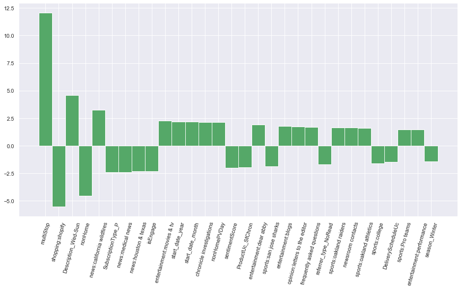

```python
fig = plt.gcf()
fig.set_size_inches(16,8, forward = False)
plt.bar(sorted_x.keys(), sorted_x.values(), width = 1, color='g')
plt.xticks(rotation = 75)
plt.show()
```

```python
from sklearn.ensemble import RandomForestClassifier

model = RandomForestClassifier(max_depth= 50, random_state=1108,
                              n_estimators=100)
model.fit(X_train[important_features], churn_next_month_train)
predictions = model.predict(X_test[important_features])
print('Prediction churn_next_month using Lasso + RandomForest:')
print('AUC: ', roc_auc_score(churn_next_month_test, predictions))
```

```
Prediction churn_next_month using Lasso + RandomForest:
AUC:  0.6077408360042439
```

# !!

```python
from sklearn.neural_network import MLPClassifier
for i in range(1):
    clf = MLPClassifier(solver='adam',activation='tanh', alpha=0.02,learning_rate = 'adaptive',
                       hidden_layer_sizes=(20,6),max_iter = 1000, random_state=i,
                       early_stopping = False)
    clf.fit(X_train[important_features], churn_next_month_train)
    predictions = clf.predict(X_test[important_features])
    # print(clf.coefs_)
    print('Prediction churn_next_month using Lasso + NN:')
    print('AUC: ', roc_auc_score(churn_next_month_test, predictions))
# i th trail, AUC:  0.669848806651173
# i th trail, AUC:  0.6794116213046703
# i th trail, AUC:  0.6935822020277536
# i th trail, AUC:  0.7057452160978276
# i th trail, AUC:  0.7044687105012473
```

```
Prediction churn_next_month using Lasso + NN:
AUC:  0.691998046322013
```

```python
# (4) Feature selection by Lasso + NN
# (5) Feature selection by Random forest + NN
```

### Prediction of rock_star_next_month (AUC)

```python
# (0) Linear regression/ logistic regerssion as baseline
model = LogisticRegression(max_iter=1000, solver="lbfgs")
model.fit(X_train, rock_star_next_month_train)

predictions = model.predict(X_test)
print('Prediction rock_star_next_month using LogisticRegression:')
print('AUC: ', roc_auc_score(rock_star_next_month_test, predictions))
```

```
Prediction rock_star_next_month using LogisticRegression:
AUC:  0.7234005512939667
```

```python
# (1) Lasso (down to 10-20 variables)
clf = LogisticRegression(penalty="l1",solver='liblinear', C = 10, random_state=123)
clf.fit(X_train, rock_star_next_month_train)
# print(clf.coef_)
print(clf.intercept_)
predictions = clf.predict(X_test)
print('Prediction rock_star_next_month using Lasso + LogisticRegression:')
print('AUC: ', roc_auc_score(rock_star_next_month_test, predictions))
```

```
[-0.63261665]
Prediction rock_star_next_month using Lasso + LogisticRegression:
AUC:  0.7445369266223911
```

```python
cols = []

important_features = []
for i in X_train.columns:
    cols.append(i)
l = list(zip(clf.coef_.tolist()[0], cols))
for i in l:
     if abs(float(i[0]))>= 0.1:
        important_features.append(i[1])
        print(i)
print(important_features)
print(len(important_features))
```

```
(-0.35031411460890904, 'ProductUc_SfChron')
(-0.30596403978691167, 'SubscriptionType_D')
(-1.067429069589098, 'SubscriptionType_P')
(-0.4202366197063585, 'Description_Fri-Sun')
(-1.3201734903320326, 'Description_iPad')
(-0.3433381070098528, 'device_type_Desktop')
(0.9253864352569375, 'device_type_Missing')
(-0.4973912183640964, 'device_type_Mobile Phone')
(-0.6510731489697346, 'device_type_Tablet')
(-0.10451669562836091, 'referrer_type_Inside Your Site')
(0.4591145910442617, 'referrer_type_NoRead')
(0.21033915223182398, 'referrer_type_Others')
(-0.4578848078183935, 'referrer_type_Search Engines')
(-0.20370902858308126, 'referrer_type_Social Networks')
(-0.5211554900289717, 'referrer_type_Typed/Bookmarked')
(1.6270716183520353, 'first_hit_referrer_type_NoRead')
(0.5917711075222746, 'first_hit_referrer_type_Other Web Sites')
(-0.2707188223327284, 'first_hit_referrer_type_Others')
(-0.14424398199285693, 'first_hit_referrer_type_Search Engines')
(-0.34905486039398875, 'first_hit_referrer_type_Social Networks')
(1.4994694702876423, 'geo_city_Missing')
(0.1268940116054825, 'geo_city_oakland')
(-0.21317648663533761, 'geo_city_san rafael')
(-0.27574146857510284, 'geo_region_California')
(0.32286704160712726, 'geo_region_Missing')
(-0.9348959832942934, 'geo_region_New York')
(-0.475030703312796, 'geo_region_Rare')
(0.9018668767968611, 'geo_country_Missing')
(-0.7483101677988527, 'geo_country_Rare')
(-0.7266050143750256, 'geo_country_United States')
(-2.3522549617790114, 'ad_block_status_Missing')
(-0.1522957419589398, 'ad_block_status_abEnabled')
(-0.3818888654313132, 'ad_block_status_noResponse')
(-3.6620407493128395, 'season_Fall')
(-0.8313625092803572, 'season_Spring')
(-1.7771018255312825, 'season_Winter')
(-0.6682825723992252, 'DeliveryScheduleUc')
(-4.693225858946445, 'month')
(-0.35125992728696875, 'time')
(0.3216656714044861, 'pv')
```

[output cut: 71 more lines]

```
(4.076811752583646, 'nonHome')
(2.4710215532557442, 'homePVPct')
(-1.1439667213610607, 'homePVDay')
(0.7817329211695774, 'nonHomePVDay')
(0.368887732491785, 'Unnamed: 0')
(1.603593285318522, 'readingDayNum_last_month')
(-5.304574688236587, 'start_date_year')
(-4.833442788587773, 'start_date_month')
(-0.14646845561504715, 'start_date_day')
(-0.790769549274954, 'multiStop')
(-0.6571658943827766, 'isEngage')
(-0.7749241110793849, 'adBlock')
(-0.40660993771276166, 'readingDayNum_last_month_NA')
['ProductUc_SfChron', 'SubscriptionType_D', 'SubscriptionType_P', 'Description_Fri-Sun', 'Description_iPad', 'device_type_Desktop', 'device_type_Missing', 'device_type_Mobile Phone', 'device_type_Tablet', 'referrer_type_Inside Your Site', 'referrer_type_NoRead', 'referrer_type_Others', 'referrer_typ…
124
```

```python
coef_dict = {}
for coef, feat in zip(clf.coef_[0],cols):
    coef_dict[feat] = coef
sorted_x = dict(sorted(coef_dict.items(), key=lambda kv: abs(kv[1]), reverse=True)[:30])
print(sorted_x)
```

```
{'sessionNum': 8.303565143959185, 'readingDayNum': 5.828090846326445, 'pvDay': -5.583974221256895, 'start_date_year': -5.304574688236587, 'start_date_month': -4.833442788587773, 'month': -4.693225858946445, 'nonHome': 4.076811752583646, 'season_Fall': -3.6620407493128395, 'sessionDay': -3.3033336289…
```

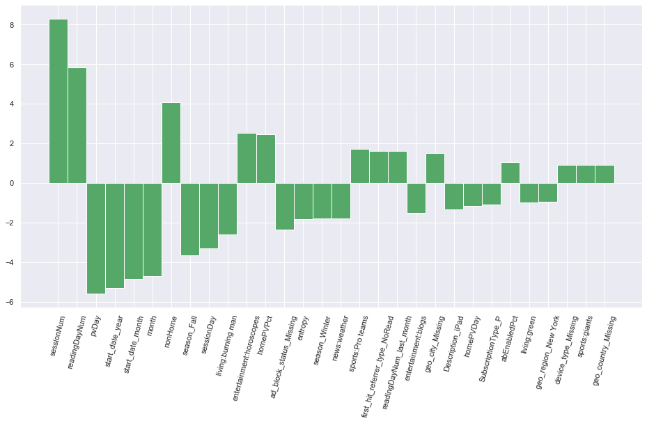

```python
fig = plt.gcf()
fig.set_size_inches(16,8, forward = False)
plt.bar(sorted_x.keys(), sorted_x.values(), width = 1, color='g')
plt.xticks(rotation = 75)
plt.show()
```

```python
# (2) Random forest (down to 10-20 variables)
model = RandomForestClassifier(max_depth= 30, random_state=1108,
                              n_estimators=100)
model.fit(X_train[important_features], rock_star_next_month_train)
predictions = model.predict(X_test[important_features])
print('Prediction rock_star_next_month using Lasso + RandomForest:')
print('AUC: ', roc_auc_score(rock_star_next_month_test, predictions))
```

```
Prediction rock_star_next_month using Lasso + RandomForest:
AUC:  0.8111964104897417
```

```python
# NN
clf = MLPClassifier(solver='adam',activation='tanh', alpha=0.01,learning_rate = 'adaptive',
                   hidden_layer_sizes=(5,3),max_iter = 2000, random_state=16889,
                   early_stopping = True)
clf.fit(X_train[important_features], rock_star_next_month_train)
predictions = clf.predict(X_test[important_features])
# print(clf.coefs_)
print('Prediction rock_star_next_month using Lasso + NN:')
print('AUC: ', roc_auc_score(rock_star_next_month_test, predictions))
```

```
Prediction rock_star_next_month using Lasso + NN:
AUC:  0.8489049516955464
```

```python
# NN
clf = MLPClassifier(solver='adam',activation='tanh', alpha=0.01,learning_rate = 'adaptive',
                   hidden_layer_sizes=(5,3),max_iter = 2000, random_state=16889,
                   early_stopping = True)
clf.fit(X_train_pca, rock_star_next_month_train)
predictions = clf.predict(X_test_pca)
# print(clf.coefs_)
print('Prediction rock_star_next_month using PCA + NN:')
print('AUC: ', roc_auc_score(rock_star_next_month_test, predictions))
```

```
Prediction rock_star_next_month using PCA + NN:
AUC:  0.6949759579025322
```

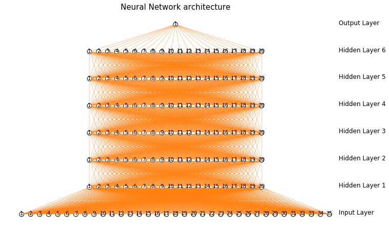

[output not shown]

```python
import VisualizeNN as VisNN
network=VisNN.DrawNN([35,20,20,20,20,20,20,1])
network.draw()
plt.show()
```